# Explore impact of Variant_Classification categories

C. Savonen for ALSF CCDL

2020

### Summary of Findings:

FoCR does not include `Translation_Start_Site`, `Nonstop_Mutation` or `Splice_Site` in the definition of nonsynonymous mutations but `maftools` does. See these [GitHub comments](https://github.com/AlexsLemonade/OpenPBTA-analysis/pull/725#issuecomment-657575733). This notebook explores how ofte those categories come up so we can know whether this will influence downstream analyses. This addresses part 2 of [this OpenPBTA issue](https://github.com/AlexsLemonade/OpenPBTA-analysis/issues/729)

### Usage

If both `run_caller_consensus_analysis-tcga.sh` and `run_caller_consensus_analysis-pbta.sh` have been run, you can run this command:

```
Rscript -e "rmarkdown::render("explore_var_class_discrepancies.Rmd", clean = TRUE)
```

**Table of Contents** *generated with [DocToc](https://github.com/thlorenz/doctoc)*

- Setup
- Read in the TMB files
  - Read in PBTA data
  - Declare Variant_Classification definitions
  - Data wranglin’
- Barplot of Variant Classification
- Session Info

## Setup

```r
# Magrittr pipe
`%>%` <- dplyr::`%>%`
```

```r
source(file.path("..", "..", "tmb-compare", "util", "cdf-plot-function.R"))
```

```r
dir.create("plots", showWarnings = FALSE)
```

## Read in the TMB files

Read in PBTA data.

```r
pbta_df <- data.table::fread(file.path(
  "..",
  "..",
  "..",
  "data",
  "pbta-snv-consensus-mutation.maf.tsv.gz"
))
```

```
|--------------------------------------------------|
|==================================================|
```

Read in TCGA data.

```r
tcga_df <- data.table::fread(file.path(
  "..",
  "results",
  "consensus",
  "tcga-snv-consensus-snv.maf.tsv.gz"
))
```

### Declare Variant_Classification definitions

```r
# These are Friends of Cancer Research included
focr_nonsynonymous <- c(
  "Missense_Mutation",
  "Frame_Shift_Del",
  "In_Frame_Ins",
  "Frame_Shift_Ins",
  "Nonsense_Mutation",
  "In_Frame_Del"
)

# These are included in maftools definition, but not FoCR
discrepant_classes <- c(
  "Translation_Start_Site",
  "Nonstop_Mutation",
  "Splice_Site"
)

# All other variant classes are considered synonymous by both mafools and FoCR
```

### Data wrangling

Summarize each dataset by these `Variant_Classification` definitions.

Do this for PBTA data.

```r
pbta_summarize_syn_df <- pbta_df %>%
  dplyr::mutate(var_def = dplyr::case_when(
    Variant_Classification %in% discrepant_classes ~ "maftools_only",
    Variant_Classification %in% focr_nonsynonymous ~ "nonsynonymous",
    TRUE ~ "synonymous"
  )) %>%
  # Group and summarize
  dplyr::group_by(Variant_Classification, var_def) %>%
  dplyr::summarize(counts = dplyr::n())
```

Repeat same steps for TCGA data.

```r
tcga_summarize_syn_df <- tcga_df %>%
  dplyr::mutate(var_def = dplyr::case_when(
    Variant_Classification %in% discrepant_classes ~ "maftools_only",
    Variant_Classification %in% focr_nonsynonymous ~ "nonsynonymous",
    TRUE ~ "synonymous"
  )) %>%
  # Group and summarize
  dplyr::group_by(Variant_Classification, var_def) %>%
  dplyr::summarize(counts = dplyr::n())
```

Let’s make this into one dataset for convenience.

```r
summarized_df <- dplyr::bind_rows(list(pbta = pbta_summarize_syn_df, tcga = tcga_summarize_syn_df),
  .id = "dataset"
) %>%
  as.data.frame() %>%
  dplyr::mutate(var_def = as.factor(var_def))
```

## Barplot of Variant Classification

Summarize by definition inclusion/exclusion.

```r
def_counts <- summarized_df %>%
  dplyr::group_by(var_def, dataset) %>%
  dplyr::summarize(total_count = sum(counts))

# Print out this table
def_counts
```

| var_def | dataset | total_count |
| --- | --- | --- |
| maftools_only | pbta | 1282 |
| maftools_only | tcga | 348 |
| nonsynonymous | pbta | 47239 |
| nonsynonymous | tcga | 15770 |
| synonymous | pbta | 1222101 |
| synonymous | tcga | 12233 |

Plot this as a barplot.

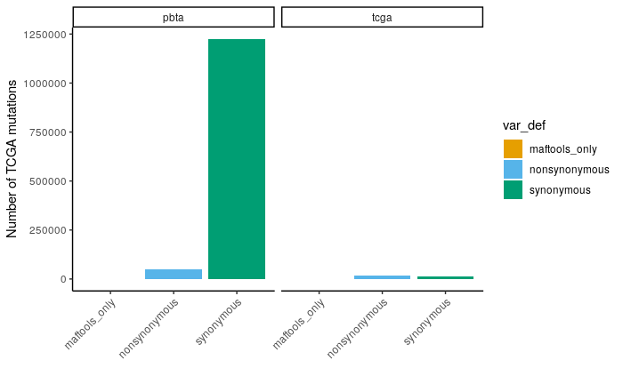

```r
  ggplot2::ggplot(def_counts, ggplot2::aes(
    x = var_def,
    y = total_count,
    fill = var_def
  )) +
  ggplot2::theme_classic() +
  ggplot2::geom_bar(
    position = "dodge", stat = "identity"
  ) +
  ggplot2::theme(axis.text.x = ggplot2::element_text(angle = 45, hjust = 1)) +
  ggplot2::xlab("") +
  ggplot2::ylab("Number of TCGA mutations") +
  colorblindr::scale_fill_OkabeIto() +
  ggplot2::facet_wrap(~dataset)
```

The discrepant classes don’t seem to show up often.